# DATA 622: Machine Learning and Big Data HW3

Gabriel Campos

Last edited May 19, 2024

# Library

```r
library(caret)
library(corrplot)
library(e1071)
library(ggplot2)
library(ggforce)
library(labelled)
library(lubridate)
library(mlbench)
library(Metrics)
library(ModelMetrics)
library(psych)
library(pROC)
library(randomForest)
library(readr)
library(RColorBrewer)
library(rpart)
library(rpart.plot)
library(tidymodels)
library(tidyverse)
```

# Description

## Decision Trees Algorithms

### Pre-work

Read this blog: https://decizone.com/blog/the-good-the-bad-the-ugly-of-using-decision-trees which shows some of the issues with decision trees.

Choose a dataset from a source in Assignment #1, or another dataset of your choice.

### Assignment work

Based on the latest topics presented, choose a dataset of your choice and create a Decision Tree where you can solve a classification problem and predict the outcome of a particular feature or detail of the data used.

Switch variables* to generate 2 decision trees and compare the results. Create a random forest and analyze the results.

Based on real cases where desicion trees went wrong, and ‘the bad & ugly’ aspects of decision trees (https://decizone.com/blog/the-good-the-bad-the-ugly-of-using-decision-trees), how can you change this perception when using the decision tree you created to solve a real problem?

### Deliverable

Essay (minimum 500 word document) Write a short essay explaining your analysis, and how you would address the concerns in the blog (listed in pre-work)

Exploratory Analysis using R or Python (submit code + errors + analysis as notebook or copy/paste to document)

* **Note:** 1. We are trying to train 2 different decision trees to compare bias and variance - so switch the features used for the first node (split) to force a different decision tree (How did the performance change?) 2. You will create 3 models: 2 x decision trees (to compare variance) and a random forest

# EDA

## Initial Exploration

```r
head(df_1k)
```

|  | Region | Country | Item.Type | Sales.Channel | Order.Priority | Order.Date | Order.ID | Ship.Date | Units.Sold | Unit.Price | Unit.Cost | Total.Revenue | Total.Cost | Total.Profit |
| --- | --- | --- | --- | --- | --- | --- | --- | --- | --- | --- | --- | --- | --- | --- |
| 1 | Middle East and North Africa | Libya | Cosmetics | Offline | M | 10/18/2014 | 686800706 | 10/31/2014 | 8446 | 437.20 | 263.33 | 3692591.20 | 2224085.2 | 1468506.02 |
| 2 | North America | Canada | Vegetables | Online | M | 11/7/2011 | 185941302 | 12/8/2011 | 3018 | 154.06 | 90.93 | 464953.08 | 274426.7 | 190526.34 |
| 3 | Middle East and North Africa | Libya | Baby Food | Offline | C | 10/31/2016 | 246222341 | 12/9/2016 | 1517 | 255.28 | 159.42 | 387259.76 | 241840.1 | 145419.62 |
| 4 | Asia | Japan | Cereal | Offline | C | 4/10/2010 | 161442649 | 5/12/2010 | 3322 | 205.70 | 117.11 | 683335.40 | 389039.4 | 294295.98 |
| 5 | Sub-Saharan Africa | Chad | Fruits | Offline | H | 8/16/2011 | 645713555 | 8/31/2011 | 9845 | 9.33 | 6.92 | 91853.85 | 68127.4 | 23726.45 |
| 6 | Europe | Armenia | Cereal | Online | H | 11/24/2014 | 683458888 | 12/28/2014 | 9528 | 205.70 | 117.11 | 1959909.60 | 1115824.1 | 844085.52 |

```r
describe(df_1k)
```

|  | vars | n | mean | sd | median | trimmed | mad | min | max | range | skew | kurtosis | se |
| --- | --- | --- | --- | --- | --- | --- | --- | --- | --- | --- | --- | --- | --- |
| Region* | 1 | 1000 | 4.30 | 2.03 | 4.00 | 4.37 | 1.48 | 1.00000e+00 | 7.00 | 6.00 | -0.09 | -1.08 | 0.06 |
| Country* | 2 | 1000 | 92.69 | 53.82 | 93.50 | 92.64 | 68.94 | 1.00000e+00 | 185.00 | 184.00 | 0.01 | -1.20 | 1.70 |
| Item.Type* | 3 | 1000 | 6.53 | 3.57 | 7.00 | 6.53 | 4.45 | 1.00000e+00 | 12.00 | 11.00 | -0.02 | -1.30 | 0.11 |
| Sales.Channel* | 4 | 1000 | 1.48 | 0.50 | 1.00 | 1.48 | 0.00 | 1.00000e+00 | 2.00 | 1.00 | 0.08 | -2.00 | 0.02 |
| Order.Priority* | 5 | 1000 | 2.49 | 1.12 | 3.00 | 2.49 | 1.48 | 1.00000e+00 | 4.00 | 3.00 | -0.02 | -1.37 | 0.04 |
| Order.Date* | 6 | 1000 | 424.45 | 244.13 | 425.00 | 425.14 | 317.28 | 1.00000e+00 | 841.00 | 840.00 | -0.02 | -1.22 | 7.72 |
| Order.ID | 7 | 1000 | 549681324.74 | 257133358.84 | 556609713.50 | 550135672.60 | 328478990.09 | 1.02928e+08 | 995529830.00 | 892601824.00 | -0.02 | -1.19 | 8131270.76 |
| Ship.Date* | 8 | 1000 | 423.04 | 241.00 | 419.50 | 423.80 | 310.60 | 1.00000e+00 | 835.00 | 834.00 | -0.01 | -1.20 | 7.62 |
| Units.Sold | 9 | 1000 | 5053.99 | 2901.38 | 5184.00 | 5066.66 | 3766.55 | 1.30000e+01 | 9998.00 | 9985.00 | -0.05 | -1.22 | 91.75 |
| Unit.Price | 10 | 1000 | 262.11 | 216.02 | 154.06 | 241.99 | 150.07 | 9.33000e+00 | 668.27 | 658.94 | 0.79 | -0.74 | 6.83 |

[output cut: 4 more lines]

```r
str(df_1k)
```

```
'data.frame':   1000 obs. of  14 variables:
 $ Region        : chr  "Middle East and North Africa" "North America" "Middle East and North Africa" "Asia" ...
 $ Country       : chr  "Libya" "Canada" "Libya" "Japan" ...
 $ Item.Type     : chr  "Cosmetics" "Vegetables" "Baby Food" "Cereal" ...
 $ Sales.Channel : chr  "Offline" "Online" "Offline" "Offline" ...
 $ Order.Priority: chr  "M" "M" "C" "C" ...
 $ Order.Date    : chr  "10/18/2014" "11/7/2011" "10/31/2016" "4/10/2010" ...
 $ Order.ID      : int  686800706 185941302 246222341 161442649 645713555 683458888 679414975 208630645 266467225 118598544 ...
 $ Ship.Date     : chr  "10/31/2014" "12/8/2011" "12/9/2016" "5/12/2010" ...
 $ Units.Sold    : int  8446 3018 1517 3322 9845 9528 2844 7299 2428 4800 ...
 $ Unit.Price    : num  437.2 154.06 255.28 205.7 9.33 ...
 $ Unit.Cost     : num  263.33 90.93 159.42 117.11 6.92 ...
 $ Total.Revenue : num  3692591 464953 387260 683335 91854 ...
 $ Total.Cost    : num  2224085 274427 241840 389039 68127 ...
 $ Total.Profit  : num  1468506 190526 145420 294296 23726 ...
```

```r
summary(df_1k)
```

```
    Region            Country           Item.Type         Sales.Channel
 Length:1000        Length:1000        Length:1000        Length:1000
 Class :character   Class :character   Class :character   Class :character
 Mode  :character   Mode  :character   Mode  :character   Mode  :character



 Order.Priority      Order.Date           Order.ID          Ship.Date
 Length:1000        Length:1000        Min.   :102928006   Length:1000
 Class :character   Class :character   1st Qu.:328074026   Class :character
 Mode  :character   Mode  :character   Median :556609714   Mode  :character
                                       Mean   :549681325
                                       3rd Qu.:769694483
                                       Max.   :995529830
   Units.Sold     Unit.Price       Unit.Cost      Total.Revenue
 Min.   :  13   Min.   :  9.33   Min.   :  6.92   Min.   :   2043
 1st Qu.:2420   1st Qu.: 81.73   1st Qu.: 56.67   1st Qu.: 281192
 Median :5184   Median :154.06   Median : 97.44   Median : 754939
 Mean   :5054   Mean   :262.11   Mean   :184.97   Mean   :1327322
 3rd Qu.:7537   3rd Qu.:421.89   3rd Qu.:263.33   3rd Qu.:1733503
 Max.   :9998   Max.   :668.27   Max.   :524.96   Max.   :6617210
   Total.Cost       Total.Profit
 Min.   :   1417   Min.   :    532.6
 1st Qu.: 164932   1st Qu.:  98376.1
 Median : 464726   Median : 277226.0
 Mean   : 936119   Mean   : 391202.6
 3rd Qu.:1141750   3rd Qu.: 548456.8
 Max.   :5204978   Max.   :1726181.4
```

```r
glimpse(df_1k)
```

```
Rows: 1,000
Columns: 14
$ Region         <chr> "Middle East and North Africa", "North America", "Middle~
$ Country        <chr> "Libya", "Canada", "Libya", "Japan", "Chad", "Armenia", ~
$ Item.Type      <chr> "Cosmetics", "Vegetables", "Baby Food", "Cereal", "Fruit~
$ Sales.Channel  <chr> "Offline", "Online", "Offline", "Offline", "Offline", "O~
$ Order.Priority <chr> "M", "M", "C", "C", "H", "H", "H", "M", "H", "H", "M", "~
$ Order.Date     <chr> "10/18/2014", "11/7/2011", "10/31/2016", "4/10/2010", "8~
$ Order.ID       <int> 686800706, 185941302, 246222341, 161442649, 645713555, 6~
$ Ship.Date      <chr> "10/31/2014", "12/8/2011", "12/9/2016", "5/12/2010", "8/~
$ Units.Sold     <int> 8446, 3018, 1517, 3322, 9845, 9528, 2844, 7299, 2428, 48~
$ Unit.Price     <dbl> 437.20, 154.06, 255.28, 205.70, 9.33, 205.70, 205.70, 10~
$ Unit.Cost      <dbl> 263.33, 90.93, 159.42, 117.11, 6.92, 117.11, 117.11, 35.~
$ Total.Revenue  <dbl> 3692591.20, 464953.08, 387259.76, 683335.40, 91853.85, 1~
$ Total.Cost     <dbl> 2224085.18, 274426.74, 241840.14, 389039.42, 68127.40, 1~
$ Total.Profit   <dbl> 1468506.02, 190526.34, 145419.62, 294295.98, 23726.45, 8~
```

```r
look_for(df_1k)
```

```
 pos variable       label    col_type missing values
 1   Region         — chr      0
 2   Country        — chr      0
 3   Item.Type      — chr      0
 4   Sales.Channel  — chr      0
 5   Order.Priority — chr      0
 6   Order.Date     — chr      0
 7   Order.ID       — int      0
 8   Ship.Date      — chr      0
 9   Units.Sold     — int      0
 10  Unit.Price     — dbl      0
 11  Unit.Cost      — dbl      0
 12  Total.Revenue  — dbl      0
 13  Total.Cost     — dbl      0
 14  Total.Profit   — dbl      0
```

```r
apply(df_1k, 2, function(x) sum(is.na(x)))
```

```
        Region        Country      Item.Type  Sales.Channel Order.Priority
             0              0              0              0              0
    Order.Date       Order.ID      Ship.Date     Units.Sold     Unit.Price
             0              0              0              0              0
     Unit.Cost  Total.Revenue     Total.Cost   Total.Profit
             0              0              0              0
```

```r
unique(df_1k$Region)
```

```
[1] "Middle East and North Africa"      "North America"
[3] "Asia"                              "Sub-Saharan Africa"
[5] "Europe"                            "Central America and the Caribbean"
[7] "Australia and Oceania"
```

```r
#unique(df_1k$Country)
```

```r
length(unique(df_1k$Country))
```

```
[1] 185
```

```r
table(df_1k$Item.Type)
```

```
      Baby Food       Beverages          Cereal         Clothes       Cosmetics
             87             101              79              78              75
         Fruits       Household            Meat Office Supplies   Personal Care
             70              77              78              89              87
         Snacks      Vegetables
             82              97
```

```r
table(df_1k$Sales.Channel)
```

```
Offline  Online
    520     480
```

```r
unique(df_1k$Order.Priority)
```

```
[1] "M" "C" "H" "L"
```

```r
#select numeric columns 1k
df_1k_num <- df_1k %>%
  keep(is.numeric)

#stats
describe(df_1k_num, fast=TRUE) %>%
  dplyr::select(c(-vars,-n))
```

|  | mean | sd | min | max | range | se |
| --- | --- | --- | --- | --- | --- | --- |
| Order.ID | 549681324.74 | 257133358.84 | 1.02928e+08 | 995529830.00 | 892601824.00 | 8131270.76 |
| Units.Sold | 5053.99 | 2901.38 | 1.30000e+01 | 9998.00 | 9985.00 | 91.75 |
| Unit.Price | 262.11 | 216.02 | 9.33000e+00 | 668.27 | 658.94 | 6.83 |
| Unit.Cost | 184.97 | 175.29 | 6.92000e+00 | 524.96 | 518.04 | 5.54 |
| Total.Revenue | 1327321.84 | 1486514.56 | 2.04325e+03 | 6617209.54 | 6615166.29 | 47007.72 |
| Total.Cost | 936119.23 | 1162570.75 | 1.41675e+03 | 5204978.40 | 5203561.65 | 36763.72 |
| Total.Profit | 391202.61 | 383640.19 | 5.32610e+02 | 1726181.36 | 1725648.75 | 12131.77 |

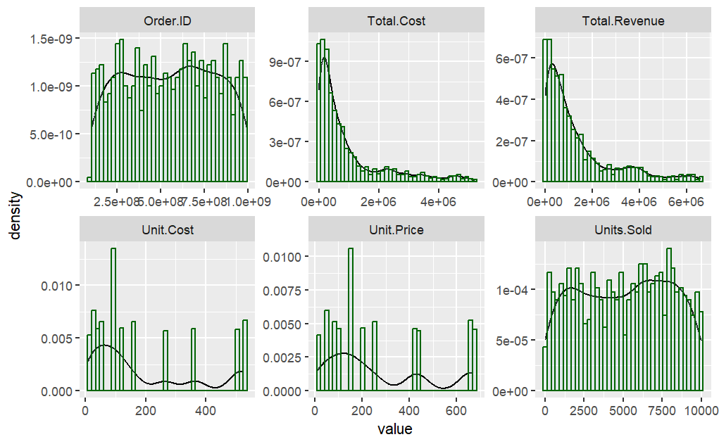

```r
#distributions
df_1k_num %>%
  pivot_longer(cols = 1:6, names_to = "variable", values_to = "value") %>%
  ggplot(aes(value)) +
    facet_wrap(~variable, scales = "free") +
    geom_density() +
    geom_histogram(aes(y = after_stat(density)), bins = 40, alpha = 0.2, fill = "lightblue", color = "darkgreen")
```

## Correlation

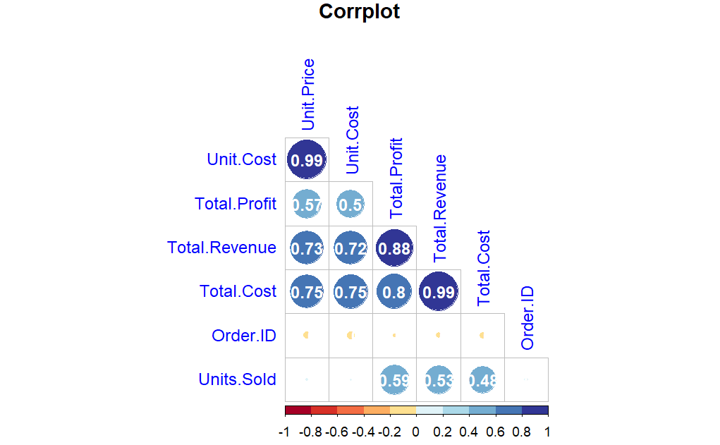

```r
corr_matrix <- cor(df_1k_num)
corrplot(corr_matrix,
         type = "lower",
         order = "hclust",
         tl.col = "blue",
         addCoef.col = "white",
         diag = FALSE,
         title = "Corrplot",
         mar = c(0, 0, 1, 0),
         col = brewer.pal(10, "RdYlBu"))
```

Looking at the correlation plot we see the following:

- Weak correlation between Unit.Price, Unit.Cost and Units.Sold
- Mild correlation between Total.Profit, Total.Revenue, Total.Cost and Units.Sold
- Mild correlation between Unit.Price, Unit.Cost and Total.Profit
- High correlation between Unit.Price and Unit.Cost
- High correlation between Total.Profit and Total Revenue
- High correlation between Total,Cost and Total.Revenue

I suspect multicollinearity but will use and additional method to confirm.

## VIF

```r
set.seed(321)

sample_1k_train <- df_1k_num$Total.Revenue %>%
  createDataPartition(p = 0.8, list = FALSE)
df_train_1k  <- df_1k_num[sample_1k_train, ]
df_test_1k <- df_1k_num[-sample_1k_train, ]


model<- lm(Total.Revenue~., data=df_train_1k )

vif_values<-car::vif(model)

print(vif_values)
```

```
    Order.ID   Units.Sold   Unit.Price    Unit.Cost   Total.Cost Total.Profit
    1.002970     3.041373   167.637725   167.273600    11.445468    14.149909
```

The values interpret as: * Order.ID has low multicollinearity * Units.Sold low multicollinearity * Unit.Price and Unit.Cost has high levels of multicollinearity * Total.Cost and Total.Profit has moderate levels of multicollinearity.

# Transformation

Only transformation needed are: * date values to Month, Day and Year * levels for categorical values. * scaling for pre-processing for modelling * Attribute selection of relevant data will also be best, which includes excluding Order.ID and Country

```r
df_1k_norm <- df_1k %>%
  mutate(
    `Order.Date` =  mdy(`Order.Date`),  # Convert to Date using lubridate's mdy function
    `Ship.Date` = mdy(`Ship.Date`),
    `Sales.Channel` = as.factor(`Sales.Channel`),
    `Order.Priority` = as.factor(`Order.Priority`),
    `Item.Type` = as.factor(`Item.Type`),
    `Region` = as.factor(`Region`),
    `Country` = as.factor(`Country`),
    `Order.ID` = as.character(`Order.ID`)
  ) %>%
  predict(preProcess(., method = c("center", "scale")), .)
```

```r
levels(df_1k_norm$Sales.Channel)
```

```
[1] "Offline" "Online"
```

```r
df_1k_norm %>%
  keep(is.numeric) %>%
  describe(fast=TRUE) %>%
  dplyr::select(-c(vars,n))
```

|  | mean | sd | min | max | range | se |
| --- | --- | --- | --- | --- | --- | --- |
| Units.Sold | 0 | 1 | -1.74 | 1.70 | 3.44 | 0.03 |
| Unit.Price | 0 | 1 | -1.17 | 1.88 | 3.05 | 0.03 |
| Unit.Cost | 0 | 1 | -1.02 | 1.94 | 2.96 | 0.03 |
| Total.Revenue | 0 | 1 | -0.89 | 3.56 | 4.45 | 0.03 |
| Total.Cost | 0 | 1 | -0.80 | 3.67 | 4.48 | 0.03 |
| Total.Profit | 0 | 1 | -1.02 | 3.48 | 4.50 | 0.03 |

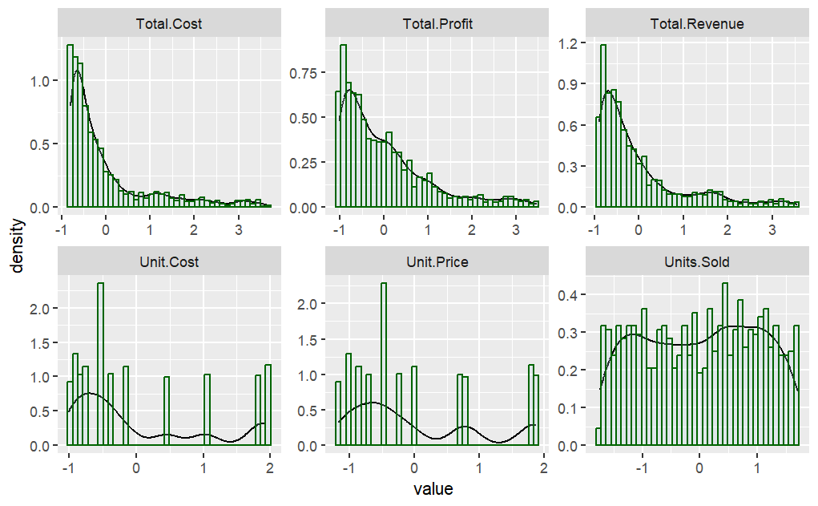

```r
#distribution
df_1k_norm %>%
  keep(is.numeric) %>%
  gather(variable, value, 1:6) %>%
  ggplot(aes(value)) +
    facet_wrap(~variable, scales = "free") +
    geom_density() +
    geom_histogram(aes(y=after_stat(density)), alpha=0.2, fill = "lightblue",
                   color="darkgreen", position="identity",bins = 40)
```

```r
df_1k_norm <- df_1k_norm %>%
  dplyr::select(-c(Country,Order.ID,))
```

# Models

## SVM

```r
set.seed(1234)

df_1k_norm_svm <- df_1k_norm
```

[output not shown]

**Note** **SVM-Kernel: radial** is the default

```r
predictions_SVM <- predict(svm_model, newdata = test_df) %>%
  bind_cols(test_df)
predictions_SVM$...1 <- as.numeric(predictions_SVM$...1)
```

### Performance and Comparison

```r
MAE <- MAE(predictions_SVM$Total.Revenue, predictions_SVM$...1)
RMSE <- RMSE(predictions_SVM$Total.Revenue, predictions_SVM$...1)
R2 <- R2(predictions_SVM$Total.Revenue, predictions_SVM$...1)

# Create a data frame to store the results
a_svm <- data.frame(Model = "SVM",
                MAE = MAE,
                RMSE = RMSE,
                R2 = R2)

# Print the results
print(a_svm)
```

| Model | MAE | RMSE | R2 |
| --- | --- | --- | --- |
| SVM | 0.04818865 | 0.06337936 | 0.9961623 |

## SLR

```r
df_1k_2 <- df_1k

preproc1 <-preProcess(df_1k_2, method=c("center", "scale"))
norm1 <- predict(preproc1,df_1k_2)

training.samples_slr <- norm1$Total.Revenue %>%
  createDataPartition(p = 0.8, list = FALSE)
train.data_slr  <- norm1[training.samples_slr, ]
test.data_slr <- norm1[-training.samples_slr, ]

model_slr<- lm(Total.Revenue~Units.Sold, data=train.data_slr )

# Make predictions
predictions_slr <- model_slr %>% predict(test.data_slr)

# Calculate the metrics
MAE_slr <- mae(predictions_slr, test.data_slr$Total.Revenue)
RMSE_slr <- RMSE(predictions_slr, test.data_slr$Total.Revenue)
R2_slr <- R2(predictions_slr, test.data_slr$Total.Revenue)

# Create a data frame to store the results
a_slr <- data.frame(Model = "Simple Linear Regression",
                     MAE = MAE_slr,
                     RMSE = RMSE_slr,
                     R2 = R2_slr)

# Print the results
print(a_slr)
```

| Model | MAE | RMSE | R2 |
| --- | --- | --- | --- |
| Simple Linear Regression | 0.6444445 | 0.8850026 | 0.2945233 |

## MLR

```r
norm2 <- norm1 %>%
  select(-c(Country, Unit.Cost, Unit.Price, Total.Cost, Total.Profit, Order.ID, Ship.Date, Order.Date))

set.seed(146)

training.samples_mlr <- norm2$Total.Revenue %>%
  createDataPartition(p = 0.8, list = FALSE)
train.data_mlr  <- norm2[training.samples_mlr, ]
test.data_mlr <- norm2[-training.samples_mlr, ]


model_mlr<- lm(Total.Revenue~., data=train.data_mlr )

test.data_mlr <- na.omit(test.data_mlr)
# Make predictions
predictions_mlr <- model_mlr %>% predict(test.data_mlr)

# Calculate the metrics
MAE_mlr <- mae(predictions_mlr, test.data_mlr$Total.Revenue)
RMSE_mlr <- RMSE(predictions_mlr, test.data_mlr$Total.Revenue)
R2_mlr <- R2(predictions_mlr, test.data_mlr$Total.Revenue)

# Create a data frame to store the results
a_mlr <- data.frame(Model = "Multiple Linear Regression",
                     MAE = MAE_mlr,
                     RMSE = RMSE_mlr,
                     R2 = R2_mlr)

# Print the results
print(a_mlr)
```

| Model | MAE | RMSE | R2 |
| --- | --- | --- | --- |
| Multiple Linear Regression | 0.3009253 | 0.4055539 | 0.8059421 |

## First Decision Tree

```r
set.seed(1234)

tree <- rpart(Total.Revenue ~., data = train_df, cp = 0.004,  method = 'anova')

predictions <- predict(tree, newdata = test_df) %>%
  bind_cols(test_df)
predictions$...1 <- as.numeric(predictions$...1)

a_tree <- data.frame(Model = "Decision Tree 1",
                #mean absolute error
                MAE = mae(predictions$Total.Revenue, predictions$...1),
                #rmse Root Mean Squared Error
                RMSE = rmse(predictions$Total.Revenue, predictions$...1),
                #r squared
                R2 = R2(predictions$Total.Revenue, predictions$...1)
)
```

## 2nd Decision Tree

```r
set.seed(123456)
#colnames(df1k_norm1)

df_1k_norm3 <- df_1k_norm %>%
  select(-c("Unit.Price","Unit.Cost","Total.Cost", "Total.Profit"))

#split
training.samples3 <- df_1k_norm3$Total.Revenue %>%
  createDataPartition(p = 0.8, list = FALSE)

train3  <- df_1k_norm3[training.samples3, ]
test3 <- df_1k_norm3[-training.samples3, ]

#train using rpart, cp- complexity, smaller # = more complexity,
#method- anova is for regression
tree3 <- rpart(Total.Revenue ~., data = train3, cp = 0.004, method = 'anova')

predictions3 <- predict(tree3, newdata = test3) %>%
  bind_cols(test3)
predictions3$...1 <- as.numeric(predictions3$...1)

a_tree2 <- data.frame(Model = "Decision Tree 2",
                #mean absolute error
                MAE = mae(predictions3$Total.Revenue, predictions3$...1),
                #rmse Root Mean Squared Error
                RMSE = rmse(predictions3$Total.Revenue, predictions3$...1),
                #r squared
                R2 = R2(predictions3$Total.Revenue, predictions3$...1)
)
```

## Random Forest

```r
set.seed(201)
rf <- randomForest(formula = Total.Revenue ~ .,
                   data = train_df, importance=TRUE)

predictions4 <- predict(rf, newdata = test_df) %>%
  bind_cols(test_df)
predictions4$...1 <- as.numeric(predictions4$...1)

a_rf <- data.frame(Model = "Random Forest",
                #mean absolute error
                MAE = mae(predictions4$Total.Revenue, predictions4$...1),
                #rmse Root Mean Squared Error
                RMSE = rmse(predictions4$Total.Revenue, predictions4$...1),
                #r squared
                R2 = R2(predictions4$Total.Revenue, predictions4$...1)
)
```

## Tuned Random Forest

```r
set.seed(908)

train1 <- train_df %>%
  dplyr::select(-Total.Revenue)

bestmtry <- tuneRF(train1,train_df$Total.Revenue, stepFactor = 2, improve = 0.01,
                   trace=T, plot= F, doBest=TRUE, importance=TRUE)
```

```
mtry = 3  OOB error = 0.002839379
Searching left ...
mtry = 2    OOB error = 0.007202836
-1.536765 0.01
Searching right ...
mtry = 6    OOB error = 0.00095211
0.6646766 0.01
mtry = 11   OOB error = 0.002508913
-1.635108 0.01
```

```r
predictions5 <- predict(bestmtry, newdata = test_df) %>%
  bind_cols(test_df)
predictions5$...1 <- as.numeric(predictions5$...1)

a_trf <- data.frame(Model = "Tuned Random Forest",
                #mean absolute error
                MAE = mae(predictions5$Total.Revenue, predictions5$...1),
                #rmse Root Mean Squared Error
                RMSE = rmse(predictions5$Total.Revenue, predictions5$...1),
                #r squared
                R2 = R2(predictions5$Total.Revenue, predictions5$...1)
)
```

```r
rbind( a_svm, a_slr, a_mlr, a_tree, a_tree2, a_trf )
```

| Model | MAE | RMSE | R2 |
| --- | --- | --- | --- |
| SVM | 0.04818865 | 0.06337936 | 0.9961623 |
| Simple Linear Regression | 0.64444446 | 0.88500264 | 0.2945233 |
| Multiple Linear Regression | 0.30092534 | 0.40555390 | 0.8059421 |
| Decision Tree 1 | 0.12156213 | 0.16606070 | 0.9737615 |
| Decision Tree 2 | 0.14830362 | 0.19035855 | 0.9677867 |
| Tuned Random Forest | 0.01200354 | 0.02333389 | 0.9995702 |

# Essay

The article [Decision Tree Ensembles to Predict Coronavirus Disease 2019 Infection: A Comparative Study](https://www.hindawi.com/journals/complexity/2021/5550344/) discusses machine learning algorithms specifically for Decision tree ensembles, to predict Covid-19 positive cases base on common lab tests. The article highlights the importance of classifiers designed for imbalanced datasets, with supporting information on how decision tree ensembles designed through classifiers for imbalanced data is better performing thatn standard methods. In the examples given, age was a major classifier in the tree ensemble, but future studies would incorporate other classifiers to understand the impact. In [A novel approach to predict COVID-19 using support vector machine](https://www.ncbi.nlm.nih.gov/pmc/articles/PMC8137961/) a paper presents a mthod with SVM classification, that predict if a person has covid-19 base on the patients symptoms. SVM classifiers notable had an accuracy of 87% based on the article. From there challenges in adaption of covid-19 was highlighted, alongside a need for ongoing analysis.

For my 3 academic papers I chose [Decision tree learning through a Predictive Model for Student Academic Performance in Intelligent M-Learning environments](https://www.sciencedirect.com/science/article/pii/S2666920X21000291), [Decision Tree-Based Predictive Models for Academic Achievement Using College Students’ Support Networks](https://arxiv.org/pdf/2108.13947) and [Using Decision Trees and Random Forest Algorithms to Predict and Determine Factors Contributing to First-Year University Students’ Learning Performance](https://www.mdpi.com/1999-4893/14/11/318). The overall theme regarding the articles was the impact of the classifiers of the decision tree. For one use case economic and demographic factors were used to identify high risk students, which allowed the school to focus on ensuring their success. In another tools such as elearning and its impact was a major factor while another used Decision tree alongside CHAID and cforest algorithms to focus on the gender identification alongside other demographic factors. Overall, I believe whats highlighted was that a diverse understanding of the use case will help in designing a model with the correct classifiers to drive results.

As far as the data used for this assignment Tuned Random Forest performed best with a MAE of 0.01200354 RMSE of 0.02333389 and R^2 of 0.9995702